# Asthma Data

UNI: jae2186 (Jennifer Estrada)

11/23/2021

## Ohio Asthma Data

```r
oh_asthma <-
  read_csv("./asthma_data/ohio_all.csv") %>%
  janitor::clean_names()
```

### Basic Ohio Visualization

Plotting data over time and looking at (1) overall trends comparing inpatient and ED visits, (2) these same trends with respect to age and race, and (3) how this looks across counties within a given year (2016).

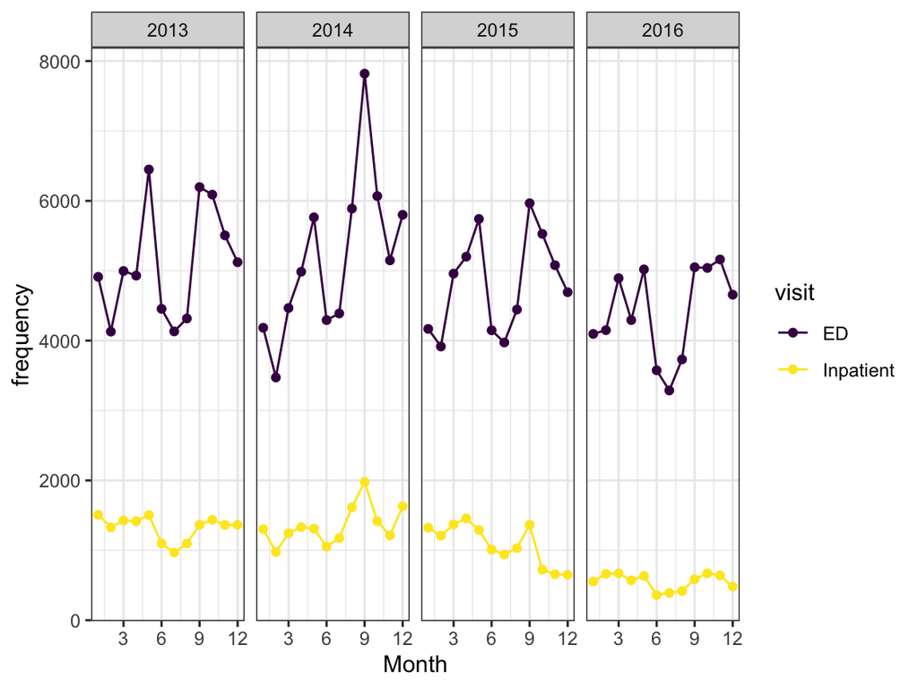

```r
oh_asthma %>%
  filter(geography == "Ohio",
         age_group == "All",
         month != "All") %>%
  mutate(month = as.numeric(month)) %>%
  ggplot(aes(x = month, y = frequency, color = visit)) +
  geom_point() +
  scale_x_continuous(name = "Month", breaks = c(0, 3, 6, 9, 12)) +
  geom_path() +
  facet_grid(. ~ year)
```

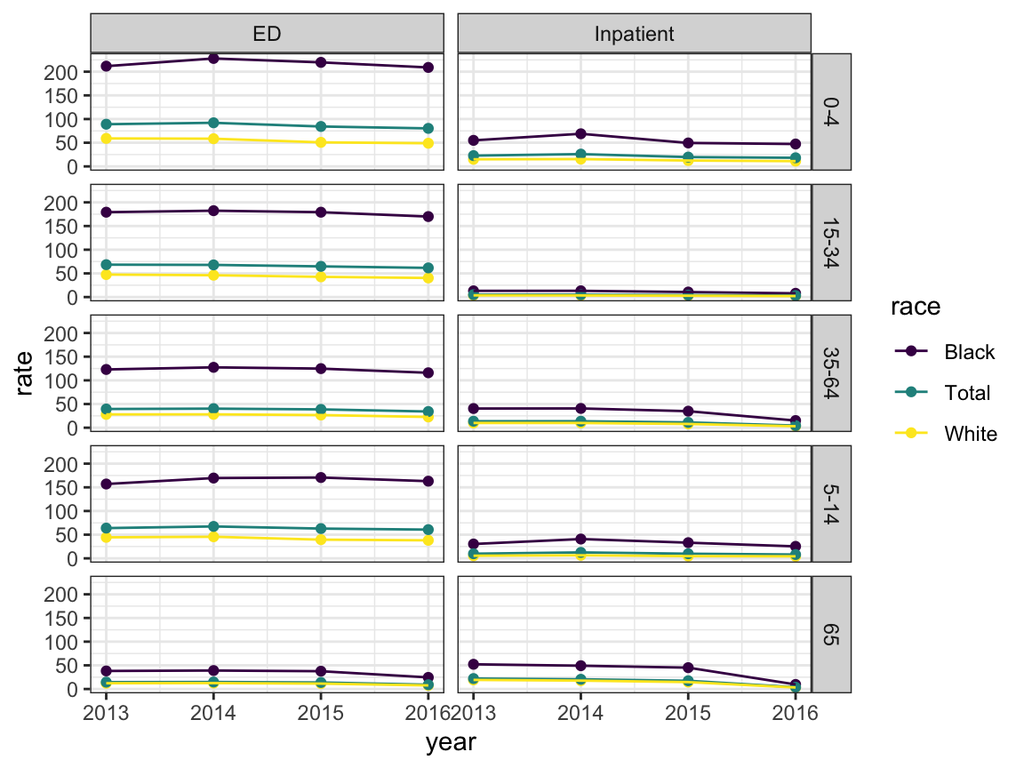

```r
oh_asthma %>%
  filter(geography == "Ohio",
         age_group != "child",
         age_group != "adult",
         age_group != "All",
         month == "All") %>%
  mutate(month = as.numeric(month)) %>%
  ggplot(aes(x = year, y = rate, color = race)) +
  geom_point() +
  geom_path() +
  facet_grid(age_group ~ visit)
```

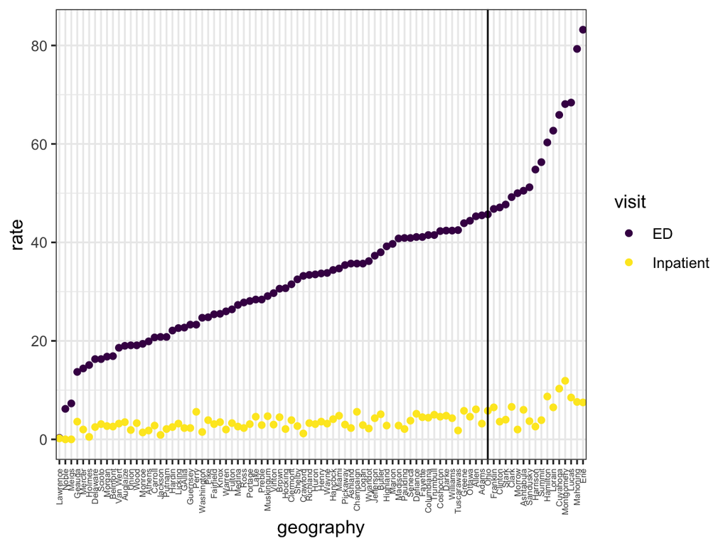

```r
oh_asthma %>%
  filter(age_group == "All",
         race == "Total",
         month == "All",
         year == "2016",
         rate != "5.5",
         rate != "43.2") %>%
  group_by(visit) %>%
  mutate(geography = fct_reorder(geography, rate)) %>%
  ggplot(aes(x = geography, y = rate, color = visit)) +
  geom_point() +
  theme(axis.text.x = element_text(angle = 90,
                                   vjust = 0.5,
                                   hjust = 1,
                                   size = 5)) +
  geom_vline(xintercept = "Ohio")
```

## New York Asthma Data

Data from New York provided as a csv file and uploaded directly

```r
ny_asthma <-
  read_csv("./asthma_data/NYS_ASTHMA.csv") %>%
  janitor::clean_names()
```

### Basic New York Visualization

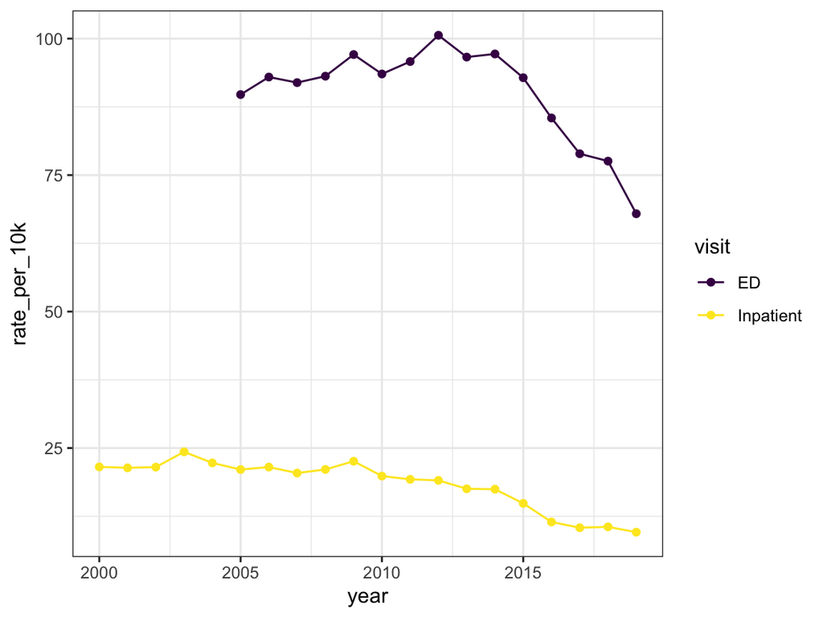

```r
years <- c("2000", "2001", "2002", "2003", "2004",
           "2005", "2006", "2007", "2008", "2009",
           "2010", "2011", "2012", "2013", "2014",
           "2015", "2016", "2017", "2018", "2019")

ny_asthma %>%
  filter(geography == "New York State",
         age_group == "Total",
         month == "Total",
         year == "2000" | year == "2001" | year == "2002" | year == "2003" |
           year == "2004" | year == "2005" | year == "2006" | year == "2007" |
           year =="2008"  | year == "2009" | year == "2010" | year == "2011" |
           year == "2012" | year == "2013" | year == "2014" | year == "2015" |
           year == "2016" | year == "2017" | year == "2018" | year == "2019",
         rate_adj == "Age-Adjusted Rate") %>%
  mutate(year = as.numeric(year)) %>%
  ggplot(aes(x = year, y = rate_per_10k, color = visit)) +
  geom_point() +
  geom_path()
```

## Pennsylvania Asthma Data

### Data Introduction

Data for PA has county level information for hospitalizations due to asthma that was obtained from the Enterprise Data Dissemination Informatics Exchange (EDDIE) as a part of Pennsylvania’s Department of Health. Data was compiled separately into one document with the option of either age-adjustment or noting crude/age-specific rates. Data include:

- `rate_adj`: notes if the data is age-adjusted or crude/age-specific rates
  - Age-Adjusted Rate is per 100,000 US 2000 standard million population.
  - Crude/Age-Specific Rate is per 100,000.
- `health_event`: hospital discharge event (all are asthma in this dataset)
- `geography`: denotes the county unless it is “Pennsylvania” which notes the state values
- `geography_code`: numerical value specific to the counties
- `year`: calendar year for data collection, in this dataset information was collected from 2000-2019
- `sex`: if data is stratified by ‘male’ or ‘female’ sex will be noted here; otherwise it is labelled as ‘total’
- `race`: options for race are ‘all races’, ‘white’, ‘black’, and ‘hispanic’
- `age`: data is age-adjusted when noted to be ‘all ages’ otherwise crude values given for adult and child categories
- `count`: number of hospitalizations
- `population`: total population meeting demographic criteria for a given count
- `rate`: rate for hospitalizations per 100 000
- `lb`: lower bound of the rate
- `ub`: upper bound of the rate
- `significance`: provided for some rates with significance denoted with “+” symbol

Notes for data:

- ND = Not displayed if count < 10 for Crude/Age Specific Rates or if count < 20 for Age-Adjusted Rates.
- Exported county data contain a + symbol indicating a significantly higher value or a - symbol indicating a significantly lower value compared to Pennsylvania.
- A note on how these data were obtained: “Hospital discharge counts reflect acute hospital visits, by county of residence, when the patient is admitted. Patients can be counted more than once if they are discharged from a hospital, for the same diagnosis, procedure, or condition during the same year. Hospital discharge coding switched from ICD-9-CM to ICD-10-CM effective October 1, 2015. ICD-10-CM codes offer greater specificity which impacts discharge counts and rates. This transition from ICD-9-CM to ICD-10-CM caused the data for certain categories to require additional processing, or appear to be out of a trend. As a result, it is recommended to re-benchmark using 2016 estimates since comparisons in counts and rates beginning in 2016 should not be compared to prior years.”
- ND = Not displayed if count < 10 for Crude/Age Specific Rates or if count < 20 for Age-Adjusted Rates.
- Exported county data contain a + symbol indicating a significantly higher value or a - symbol indicating a significantly lower value compared to Pennsylvania.
- A note on how these data were obtained:
  - *“Hospital discharge counts reflect acute hospital visits, by county of residence, when the patient is admitted. Patients can be counted more than once if they are discharged from a hospital, for the same diagnosis, procedure, or condition during the same year. Hospital discharge coding switched from ICD-9-CM to ICD-10-CM effective October 1, 2015. ICD-10-CM codes offer greater specificity which impacts discharge counts and rates. This transition from ICD-9-CM to ICD-10-CM caused the data for certain categories to require additional processing, or appear to be out of a trend. As a result, it is recommended to re-benchmark using 2016 estimates since comparisons in counts and rates beginning in 2016 should not be compared to prior years.”*

### Obtaining data

```r
pa_asthma <-
  read_csv("./asthma_data/pa_asthma_all.csv", col_names = TRUE) %>%
  janitor::clean_names()
```

### Basic Pennsylvania Visualization

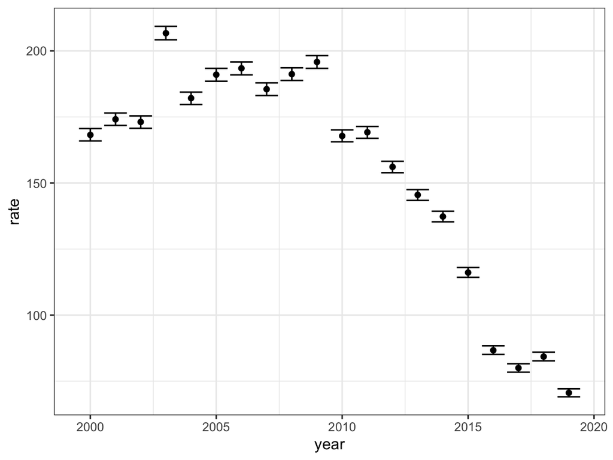

```r
pa_asthma %>%
  filter(race == "All Races",
         age == "All Ages",
         sex == "Total",
         geography == "Pennsylvania") %>%
  mutate(rate = as.numeric(rate),
         lb = as.numeric(lb),
         ub = as.numeric(ub)) %>%
  ggplot(aes(x = year, y = rate)) +
  geom_point() +
  geom_errorbar(aes(ymin = lb, ymax = ub))
```

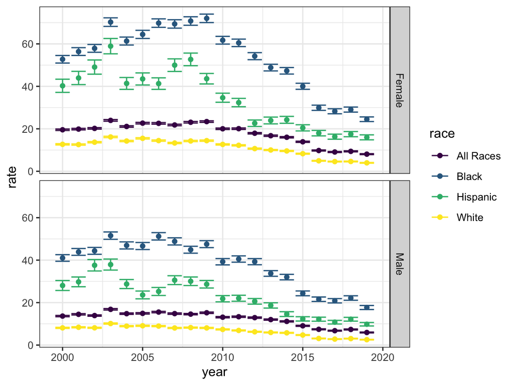

```r
pa_asthma %>%
  filter(geography_code == "0",
         sex != "Total",
         age == "All Ages") %>%
  mutate(rate = as.numeric(rate) / 10,
         lb = as.numeric(lb) / 10,
         ub = as.numeric(ub) / 10) %>%
  ggplot(aes(x = year, y = rate, color = race)) +
  geom_point() +
  geom_errorbar(aes(ymin = lb, ymax = ub)) +
  facet_grid(sex ~ .)
```

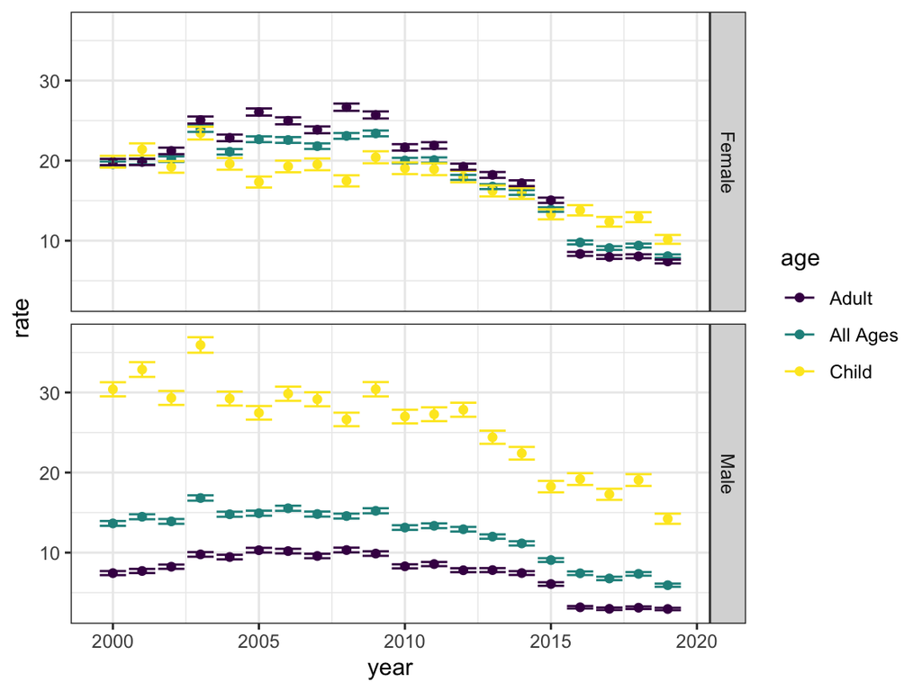

```r
pa_asthma %>%
  filter(geography_code == "0",
         sex != "Total",
         race == "All Races") %>%
  mutate(rate = as.numeric(rate) / 10,
         lb = as.numeric(lb) / 10,
         ub = as.numeric(ub) / 10) %>%
  ggplot(aes(x = year, y = rate, color = age)) +
  geom_point() +
  geom_errorbar(aes(ymin = lb, ymax = ub)) +
  facet_grid(sex ~ .)
```

## Comparing data across states

### Maps

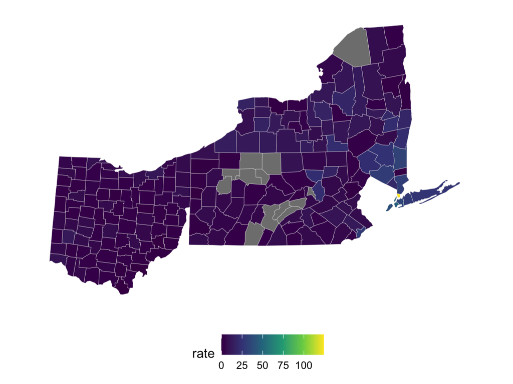

```r
ny_co <-
  ny_asthma %>%
  filter(age_group == "Total",
         month == "Total",
         year == "2015-2017",
         visit == "Inpatient",
         rate_adj == "Age-Adjusted Rate",
         geography != "New York State",
         geography != "New York City") %>%
  mutate(county = tolower(geography),
         rate = rate_per_10k,
         region = "new york",
         county = replace(county,
                          county == "new york county", "new york")) %>%
  select(region, county, rate) %>%
  group_by(county)


oh_co <-
  oh_asthma %>%
  filter(geography != "Ohio",
         age_group == "All",
         visit == "Inpatient") %>%
  mutate(county = tolower(geography),
         region = "ohio") %>%
  select(region, county, rate) %>%
  group_by(county)


pa_co <-
  pa_asthma %>%
  filter(geography_code != "0",
         rate_adj == "Age-Adjusted Rate",
         year == "2016",
         age == "All Ages") %>%
  mutate(county = tolower(geography),
         region = "pennsylvania",
         rate = as.numeric(rate) / 10) %>%
  select(region, county, rate) %>%
  group_by(county)

county_2016 <-
  bind_rows(oh_co, ny_co, pa_co)

us_counties %>%
  filter(region == "ohio"|
           region == "new york" |
           region == "pennsylvania" ) %>%
  left_join(county_2016, by = c("subregion" = "county")) %>%
  ggplot(aes(x = long, y = lat, group = group, fill = rate)) +
  geom_polygon(color = "gray90", size = 0.1) +
  #coord_map(projection = "albers", lat0 = 39, lat1 = 45) +
  coord_map(projection = "albers", lat0 = 45, lat1 = 55) +
  scale_fill_continuous(type = "viridis")+
  #scale_fill_brewer("Oranges")+
  theme(legend.position = "bottom",
        axis.line = element_blank(),
        axis.text = element_blank(),
        axis.ticks = element_blank(),
        axis.title = element_blank(),
        panel.background = element_blank(),
        panel.border = element_blank(),
        panel.grid = element_blank())
```

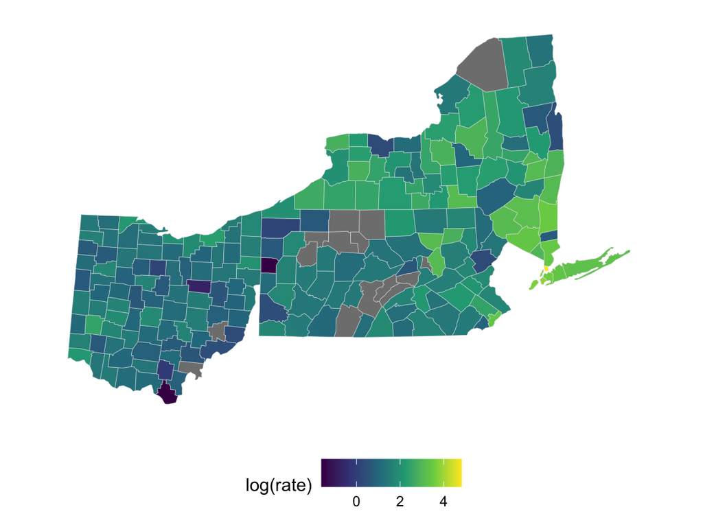

```r
us_counties %>%
  filter(region == "ohio"|
           region == "new york" |
           region == "pennsylvania" ) %>%
  left_join(county_2016, by = c("subregion" = "county")) %>%
  ggplot(aes(x = long, y = lat, group = group, fill = log(rate))) +
  geom_polygon(color = "gray90", size = 0.1) +
  #coord_map(projection = "albers", lat0 = 39, lat1 = 45) +
  coord_map(projection = "albers", lat0 = 45, lat1 = 55) +
  scale_fill_continuous(type = "viridis")+
  #scale_fill_brewer("Oranges")+
  theme(legend.position = "bottom",
        axis.line = element_blank(),
        axis.text = element_blank(),
        axis.ticks = element_blank(),
        axis.title = element_blank(),
        panel.background = element_blank(),
        panel.border = element_blank(),
        panel.grid = element_blank())
```

### Graphs

Boxplots to contrast states/regions - one boxplot for asthma all years available:

- Rates per 10 000 for 2013-2016 (includes all races, ages, and sexes) for hospitalizations

Scatterplots/spaghetti plots for disease trends over time

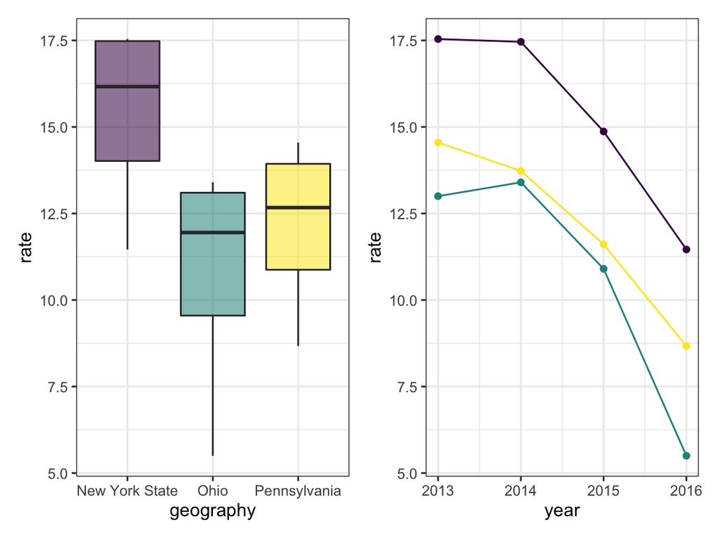

```r
oh_bp <-
  oh_asthma %>%
  filter(geography == "Ohio",
         age_group == "All",
         month == "All",
         race == "Total",
         population > 0,
         visit == "Inpatient") %>%
  select(year, geography, rate)

ny_bp <-
  ny_asthma %>%
  filter(geography == "New York State",
         age_group == "Total",
         month == "Total",
         year == "2013" | year == "2014" | year == "2015" | year == "2016",
         rate_adj == "Age-Adjusted Rate",
         visit == "Inpatient") %>%
  mutate(year = as.numeric(year)) %>%
  rename(rate = rate_per_10k) %>%
  select(year, geography, rate)

pa_bp <-
  pa_asthma %>%
  filter(race == "All Races",
         age == "All Ages",
         sex == "Total",
         geography == "Pennsylvania",
         year > 2012,
         year <2017) %>%
  mutate(rate = as.numeric(rate) / 10,
         lb = as.numeric(lb),
         ub = as.numeric(ub)) %>%
  select(year, geography, rate)

all_bp_data <-
  bind_rows(pa_bp, oh_bp, ny_bp)

all_bp <-
  all_bp_data %>%
  ggplot(aes(x = geography, y = rate, fill = geography, alpha = 0.5)) +
  geom_boxplot() +
  theme(legend.position = "none")

all_line <-
  all_bp_data %>%
  ggplot(aes(x = year, y = rate, color = geography )) +
  geom_point() +
  geom_path() +
  theme(legend.position = "none")


all_bp + all_line
```

## Merging Data

```r
oh_state <-
  oh_asthma %>%
  filter(age_group == "All",
         month == "All",
         race == "Total",
         sex == "All",
         geography == "Ohio",
         visit == "Inpatient",
         frequency > 0) %>%
  rename(state = geography) %>%
  mutate(rate = rate * 10,
         outcome = "asthma",
         state = "OH") %>%
  select(year, state, outcome, rate)

pa_state <-
  pa_asthma %>%
  filter(age == "All Ages",
         race == "All Races",
         sex == "Total",
         geography_code == "0",
         rate_adj == "Age-Adjusted Rate") %>%
  rename(state = geography) %>%
  mutate(outcome = "asthma",
         state = "PA") %>%
  select(year, state, outcome, rate)

ny_state <-
  ny_asthma %>%
  filter(visit == "Inpatient",
         geography == "New York State",
         age_group == "Total",
         sex == "Total",
         rate_adj == "Age-Adjusted Rate",
         month == "Total",
         str_detect(year, "-20", negate = TRUE)) %>%
  rename(rate = rate_per_10k) %>%
  mutate(rate = round(rate * 10, 2),
         state = "NY",
         outcome = "asthma") %>%
  select(year, state, outcome, rate)

asthma_state <-
  rbind(ny_state, oh_state, pa_state) %>%
  write_csv("./asthma_state.csv")
```

```r
ny_county <-
  ny_asthma %>%
  filter(visit == "Inpatient",
         geography != "New York State",
         geography != "New York City",
         geography != "NYS excluding NYC",
         rate_adj == "Age-Adjusted Rate",
         sex == "Total",
         age_group == "Total",
         rate_per_10kpy >= 0) %>%
  rename(county = geography) %>%
  mutate(outcome = "asthma",
         state = "NY",
         year = str_sub(year, 6, -1),
         rate = rate_per_10kpy * 10) %>%
  filter(year != "2019") %>%
  select(year, state, county, outcome, rate)

pa_county <-
  pa_asthma %>%
  filter(geography_code != "0",
         rate_adj == "Age-Adjusted Rate",
         sex == "Total",
         age == "All Ages") %>%
  rename(county = geography) %>%
  mutate(outcome = "asthma",
         state = "PA") %>%
  select(year, state, county, outcome, rate)

oh_county <-
  oh_asthma %>%
  filter(geography != "Ohio",
         age_group == "All",
         visit == "Inpatient") %>%
  mutate(state = "OH",
         rate = rate * 10,
         outcome = "asthma") %>%
  rename(county = geography) %>%
  select(year, state, county, outcome, rate)

asthma_county <-
  rbind(ny_county, oh_county, pa_county) %>%
  write_csv("./asthma_county.csv")
```